# Prior Predictive Checks: Reaction Time Example

Bayesian Mixed Effects Models with brms for Linguists

Author

Job Schepens

Published

December 17, 2025

# 1 Prior Predictive Checks for Reaction Time Data

This document demonstrates how to validate priors for a Bayesian RT model before fitting to data.

## 1.1 Why Prior Predictive Checks Matter

Before fitting your model to actual data, validate that your priors generate sensible predictions. This is crucial because:

- A prior that’s too restrictive can prevent the model from learning from data
- A prior that’s too permissive might not regularize your estimates
- It’s much easier to revise priors before fitting than after

## 1.2 Setup

```r
library(brms)
library(tidyverse)
library(bayesplot)
library(posterior)  # For as_draws_df() - following Kurz's approach

# Create example RT data
set.seed(42)
n_subj <- 20
n_trials <- 50
n_items <- 30

rt_data <- expand.grid(
  trial = 1:n_trials,
  subject = 1:n_subj,
  item = 1:n_items
) %>%
  filter(row_number() <= n_subj * n_trials * 3) %>%
  mutate(
    condition = rep(c("A", "B"), length.out = n()),
    log_rt = rnorm(n(), mean = 6, sd = 0.3) +
             (condition == "B") * 0.15 +
             rnorm(n(), mean = 0, sd = 0.1),
    rt = exp(log_rt)
  )

# Define priors
rt_priors <- c(
  prior(normal(6, 1.5), class = Intercept),
  prior(normal(0, 0.5), class = b),
  prior(exponential(1), class = sigma),
  prior(exponential(1), class = sd),
  prior(lkj(2), class = cor)
)
```

## 1.3 Fitting Prior Only Model

```r
# Create fits directory if it doesn't exist
if (!dir.exists("fits")) dir.create("fits")

# Fit model with priors only
# Using file argument to cache the fitted model and speed up re-runs
prior_pred <- brm(
  log_rt ~ condition + (1 + condition | subject) + (1 | item),
  data = rt_data,
  family = gaussian(),
  prior = rt_priors,
  sample_prior = "only",
  chains = 4, iter = 1000,  # 4 chains, fewer iterations for prior checks
  cores = 4,                 # Use 4 cores for parallel sampling
  verbose = FALSE,
  refresh = 0,
  file = "fits/prior_pred_rt",  # Cache model - only refits if data/formula/priors change
  file_refit = "on_change"       # Only refit when necessary
)
```

[output not shown]

[figure not shown]

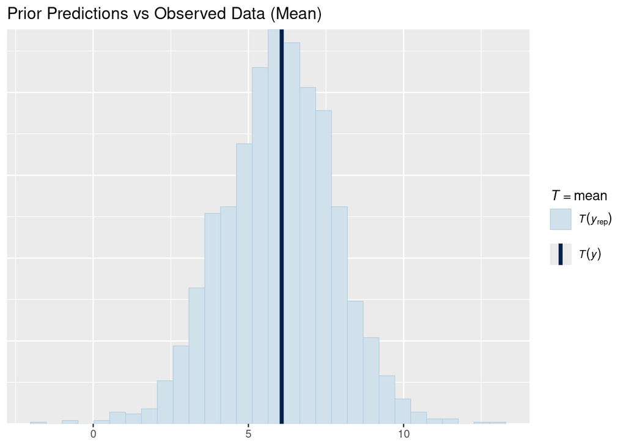

```r
# Mean comparison
pp_check(prior_pred, type = "stat", stat = "mean") +
  labs(title = "Prior Predictions vs Observed Data (Mean)")
```

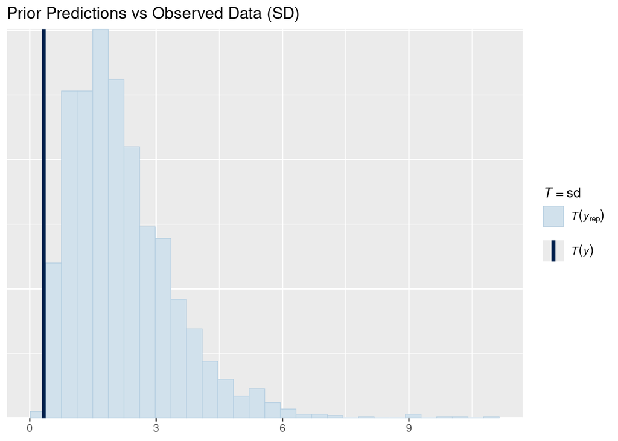

```r
# SD comparison
pp_check(prior_pred, type = "stat", stat = "sd") +
  labs(title = "Prior Predictions vs Observed Data (SD)")
```

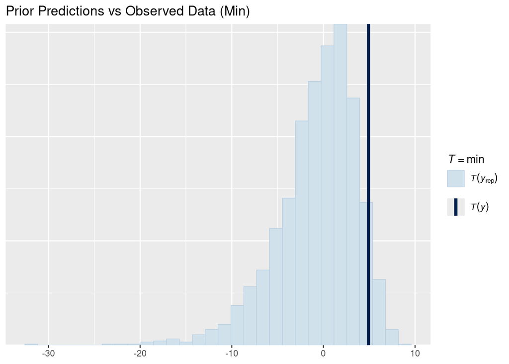

```r
# Min comparison
pp_check(prior_pred, type = "stat", stat = "min") +
  labs(title = "Prior Predictions vs Observed Data (Min)")
```

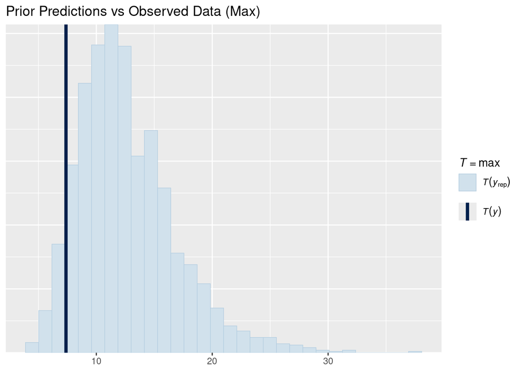

```r
# Max comparison
pp_check(prior_pred, type = "stat", stat = "max") +
  labs(title = "Prior Predictions vs Observed Data (Max)")
```

## 1.4 Prior Distributions

Following Kurz’s approach, we extract prior samples using `as_draws_df()` from the posterior package.

```r
# Extract prior draws as a data frame (Kurz's method)
# This works seamlessly with tidyverse and gives us a proper data frame
library(posterior)
prior_samples <- as_draws_df(prior_pred)
```

### 1.4.1 Intercept Prior

```r
# Now we can access columns directly from the data frame
intercept_vals <- prior_samples$b_Intercept

cat("Intercept prior (log scale):\n")
```

```
Intercept prior (log scale):
```

```r
print(quantile(intercept_vals, c(0.025, 0.5, 0.975), na.rm = TRUE))
```

```
    2.5%      50%    97.5%
2.875128 6.020023 8.923694
```

```r
cat("\nIntercept prior (RT scale in milliseconds):\n")
```

```
Intercept prior (RT scale in milliseconds):
```

```r
print(exp(quantile(intercept_vals, c(0.025, 0.5, 0.975), na.rm = TRUE)))
```

```
      2.5%        50%      97.5%
  17.72769  411.58799 7507.77385
```

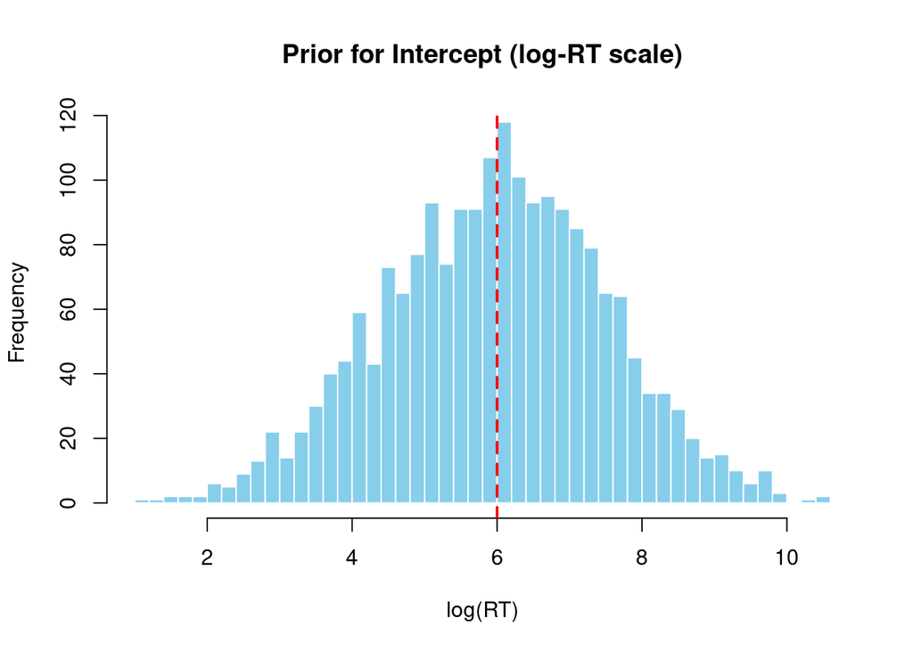

```r
# Visualization
hist(intercept_vals,
     main = "Prior for Intercept (log-RT scale)",
     xlab = "log(RT)",
     breaks = 50, col = "skyblue", border = "white")
abline(v = 6, col = "red", lwd = 2, lty = 2)
```

### 1.4.2 Effect Size Prior

```r
effect_vals <- prior_samples$b_conditionB

cat("Condition effect prior (log scale):\n")
```

```
Condition effect prior (log scale):
```

```r
effect_q <- quantile(effect_vals, c(0.025, 0.5, 0.975), na.rm = TRUE)
print(effect_q)
```

```
       2.5%         50%       97.5%
-0.99889479 -0.01414723  0.94791795
```

```r
cat("\nCondition effect prior (RT scale in ms):\n")
```

```
Condition effect prior (RT scale in ms):
```

```r
print(exp(effect_q))
```

```
     2.5%       50%     97.5%
0.3682863 0.9859524 2.5803317
```

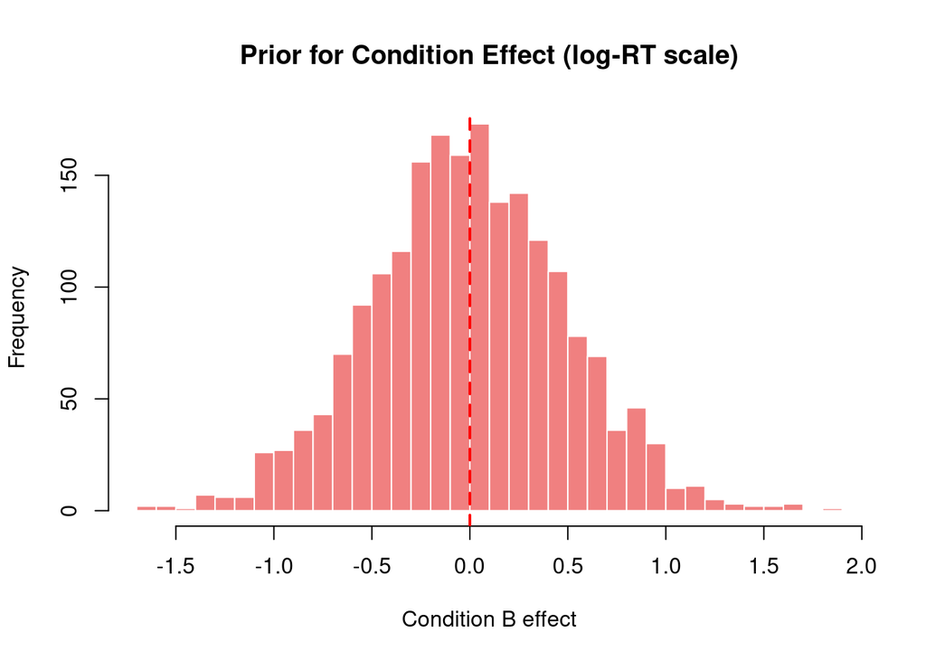

```r
# Visualization
hist(effect_vals,
     main = "Prior for Condition Effect (log-RT scale)",
     xlab = "Condition B effect",
     breaks = 50, col = "lightcoral", border = "white")
abline(v = 0, col = "red", lwd = 2, lty = 2)
```

### 1.4.3 Residual Noise Prior

```r
sigma_vals <- prior_samples$sigma

cat("Residual noise prior (sigma, log scale):\n")
```

```
Residual noise prior (sigma, log scale):
```

```r
sigma_q <- quantile(sigma_vals, c(0.025, 0.5, 0.975), na.rm = TRUE)
print(sigma_q)
```

```
      2.5%        50%      97.5%
0.02573465 0.69876976 3.81711126
```

## 1.5 Random Effects Distributions

For prior predictive checks, we examine the **implied distribution** of subject-specific parameters by extracting the hyperprior SDs and simulating random effects.

### 1.5.1 Subject Random Intercepts

```r
# Extract hyperprior SDs from prior samples
sd_subject_intercept <- prior_samples$sd_subject__Intercept

cat("Subject random intercept SD prior:\n")
```

```
Subject random intercept SD prior:
```

```r
print(quantile(sd_subject_intercept, c(0.025, 0.5, 0.975)))
```

```
      2.5%        50%      97.5%
0.02519548 0.67840017 3.61983168
```

```r
# Simulate random effects from this prior
set.seed(123)
n_sims <- 1000
simulated_intercepts <- rnorm(n_sims, mean = 0, sd = median(sd_subject_intercept))

cat("\nImplied subject random intercepts (log scale):\n")
```

```
Implied subject random intercepts (log scale):
```

```r
subject_int <- quantile(simulated_intercepts, c(0.025, 0.5, 0.975))
print(subject_int)
```

```
        2.5%          50%        97.5%
-1.317150788  0.006247821  1.382502744
```

```r
cat("\nImplied subject-specific RTs (milliseconds):\n")
```

```
Implied subject-specific RTs (milliseconds):
```

```r
# Combine with typical intercept value from prior
intercept_median <- median(intercept_vals)
subject_rt <- exp(intercept_median + subject_int)
print(subject_rt)
```

```
     2.5%       50%     97.5%
 110.2634  414.1676 1640.1214
```

```r
cat("Prior implies subject RTs range from",
    round(subject_rt[1]), "to", round(subject_rt[3]), "ms\n")
```

```
Prior implies subject RTs range from 110 to 1640 ms
```

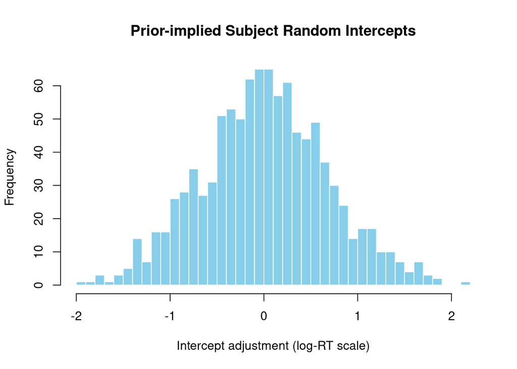

```r
# Visualization
hist(simulated_intercepts,
     main = "Prior-implied Subject Random Intercepts",
     xlab = "Intercept adjustment (log-RT scale)",
     breaks = 30, col = "skyblue", border = "white")
```

### 1.5.2 Subject Random Slopes

```r
# Extract hyperprior SDs for slopes
sd_subject_slope <- prior_samples$sd_subject__conditionB

cat("Subject random slope SD prior:\n")
```

```
Subject random slope SD prior:
```

```r
print(quantile(sd_subject_slope, c(0.025, 0.5, 0.975)))
```

```
     2.5%       50%     97.5%
0.0249993 0.6998014 3.6529919
```

```r
# Simulate random slope effects
simulated_slopes <- rnorm(n_sims, mean = 0, sd = median(sd_subject_slope))

cat("\nImplied subject random slopes (log scale):\n")
```

```
Implied subject random slopes (log scale):
```

```r
subject_slope <- quantile(simulated_slopes, c(0.025, 0.5, 0.975))
print(subject_slope)
```

```
       2.5%         50%       97.5%
-1.39369961  0.03838577  1.33375954
```

```r
cat("\nInterpretation: Condition effect varies by subject\n")
```

```
Interpretation: Condition effect varies by subject
```

```r
cat("Small effect subjects (2.5%): ", round(exp(subject_slope[1]), 3), "× multiplier\n")
```

```
Small effect subjects (2.5%):  0.248 × multiplier
```

```r
cat("Average effect subjects (50%): ", round(exp(subject_slope[2]), 3), "× multiplier\n")
```

```
Average effect subjects (50%):  1.039 × multiplier
```

```r
cat("Large effect subjects (97.5%): ", round(exp(subject_slope[3]), 3), "× multiplier\n")
```

```
Large effect subjects (97.5%):  3.795 × multiplier
```

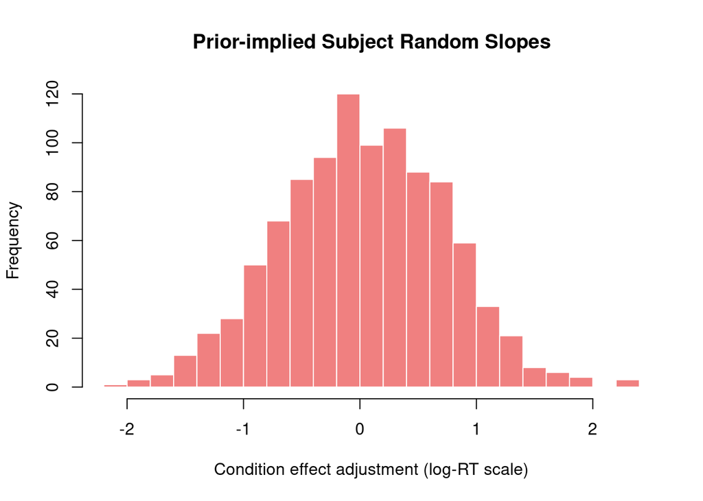

```r
# Visualization
hist(simulated_slopes,
     main = "Prior-implied Subject Random Slopes",
     xlab = "Condition effect adjustment (log-RT scale)",
     breaks = 30, col = "lightcoral", border = "white")
```

### 1.5.3 Residual Noise Distribution

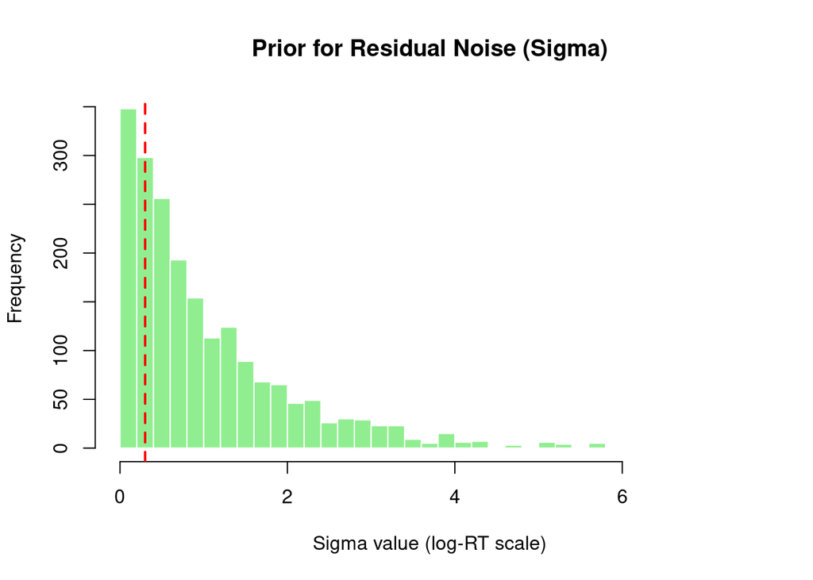

```
Interpretation: Red line shows typical residual SD (0.3) for RT data
Our prior puts 25.4 % probability below this value
```

```r
if (!is.null(sigma_vals) && is.numeric(sigma_vals)) {
  hist(sigma_vals,
       main = "Prior for Residual Noise (Sigma)",
       xlab = "Sigma value (log-RT scale)",
       breaks = 30, col = "lightgreen", border = "white")
  abline(v = 0.3, col = "red", lwd = 2, lty = 2)

  cat("\nInterpretation: Red line shows typical residual SD (0.3) for RT data\n")
  cat("Our prior puts", round(mean(sigma_vals < 0.3) * 100, 1),
      "% probability below this value\n")
} else {
  plot(1, main = "Sigma visualization", xlab = "", ylab = "")
  text(1, 1, "Sigma samples not available")
}
```

### 1.5.4 Random Effects Comparison

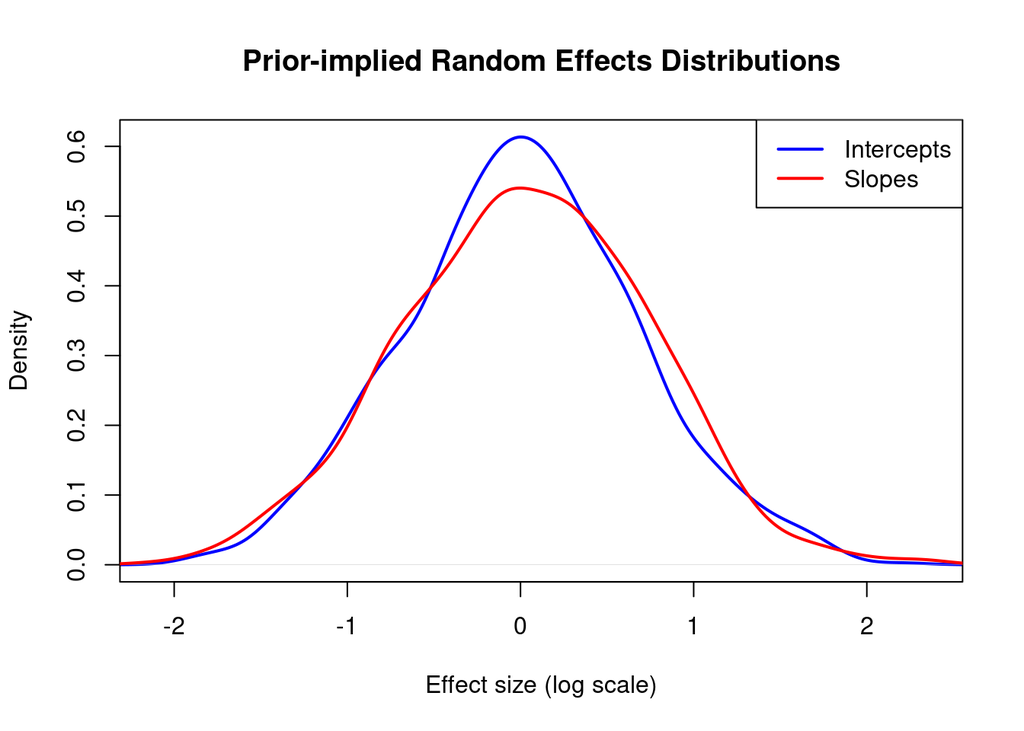

```r
# Density plot comparing intercepts and slopes
plot(density(simulated_intercepts),
     main = "Prior-implied Random Effects Distributions",
     xlab = "Effect size (log scale)",
     col = "blue", lwd = 2, xlim = range(c(simulated_intercepts, simulated_slopes)),
     ylim = c(0, max(density(simulated_intercepts)$y, density(simulated_slopes)$y)))
lines(density(simulated_slopes),
      col = "red", lwd = 2)
legend("topright", c("Intercepts", "Slopes"), col = c("blue", "red"), lwd = 2)
```

## 1.6 Interpretation

### 1.6.2 Problems to Watch For

- ✗ Mean RT >> 1000ms: intercept prior too high
- ✗ 95% interval 10ms-50s: priors too wide
- ✗ No variation between subjects: SD priors too small

## 1.7 Summary

Before fitting your model to actual data, always validate that your priors: 1. Generate reasonable predictions 2. Allow the data to inform the posterior 3. Respect domain knowledge constraints

Adjust priors as needed and rerun these checks.